# Healthy Control Samples

Anna Korda

2025-05-11

## A 16S study with Healthy Donor Samples

This study (https://www.ebi.ac.uk/ena/browser/view/PRJEB41316) profiles the gut microbiome of carefully screened stool donors from a universal stool bank, using 16S rRNA sequencing on 200 samples from 86 donors. With **detailed lifestyle metadata and strict donor selection**, it offers a rare and **valuable reference for defining healthy gut microbiome baselines**. We used their official pipeline from OpenBiome’s Github https://github.com/openbiome/donors-16s/tree/v1.1, running the full Snakemake workflow and performing additional analysis to identify the most central, representative healthy control samples.

*This study was not available in MGnify

```r
library(tidyverse)
library(readxl)
library(vegan)
library(compositions)
library(robustbase)
library(gridExtra)
```

## File inputs

The input files used in this analysis were generated by running the Snakemake pipeline provided by the authors of the dataset via GitHub. Specifically, we used otu_table.tsv (containing OTU abundance counts) and the beta-diversity results (beta.tsv) exported by the pipeline. Additional files such as metadata.csv (sample and sequencing metadata) and donor_health_data.xlsx (lifestyle and health information of each donor) were already included in the dataset release and required no preprocessing.

## Filtering Steps

```r
# Load beta.tsv to extract used sample IDs
beta_tibble <- read_tsv("beta.tsv")
sample_ids <- beta_tibble[[1]]  # first column (sample names used)

# Subset metadata to only those samples the authors used
metadata_matched <- metadata_health %>%
  filter(sample_id %in% sample_ids)

# Apply YOUR filters exactly
step3 <- metadata_matched %>%
  filter(
    between(`Donor BMI`, 18.5, 25),
    trimws(`List of medications taken by donor (If any)`) == "N/A",
    trimws(`Donor's known allergies (if any)`) == "N/A",
    is.na(`Donor's average weekly alcohol usage (if known)`) | alcohol_int <= 2
  )

# Load OTU table and subset to filtered samples
otu <- read_tsv("otu_table.tsv", skip = 1) %>%
  rename(otu_id = `#OTU ID`) %>%
  column_to_rownames("otu_id")

otu_filtered <- otu[, step3$sample_id]
```

## Identifying Central Healthy Profiles Using Multivariate Statistics

To define the most representative healthy controls, we **normalized the OTU table using a Centered Log-Ratio (CLR) transformation**, which is appropriate for compositional microbiome data. We then applied **Principal Component Analysis (PCA) to reduce dimensionality**, ensuring compatibility with **Mahalanobis distance estimation**. This distance **quantifies how far each sample lies from the center of the distribution in multivariate space**. Our approach is conceptually similar to the **CLOUD test** introduced by **Montassier et al.(2018)** (https://doi.org/10.1186/s40168-018-0514-4), which identifies microbial community deviations by evaluating distances from a healthy reference cloud. We used this idea to rank healthy samples and select those closest to the **“core” healthy microbiome profile.**

```r
# CLR transform
otu_clr <- clr(otu_filtered + 1)

# Transpose to get samples as rows
otu_clr_t <- t(otu_clr)

# Remove constant columns (zero variance)
otu_clr_t_nz <- otu_clr_t[, apply(otu_clr_t, 2, var) != 0]

# PCA
otu_pca <- prcomp(otu_clr_t_nz, center = TRUE, scale. = TRUE)
pca_coords <- otu_pca$x[, 1:10]

# Mahalanobis with fixed seed
set.seed(42) #reproducibility
mahal <- covMcd(pca_coords)
distances <- mahalanobis(pca_coords, center = mahal$center, cov = mahal$cov)

# Match to samples and merge
sample_ids <- rownames(pca_coords)
distances_df <- tibble(sample_id = sample_ids, mahalanobis = distances)

step3_ranked <- step3 %>%
  inner_join(distances_df, by = "sample_id") %>%
  arrange(mahalanobis)
```

## Output

We selected the top 5 most central healthy control samples, based on Mahalanobis distance, to serve as a reference baseline for our own pipeline.

```
## # A tibble: 5 × 5
##   sample_id donor    `Donor BMI` alcohol_int mahalanobis
##   <chr>     <chr>          <dbl>       <int>       <dbl>
## 1 sample105 FT-10122        18.8           2        1.97
## 2 sample067 FT-10120        21.6           1        2.25
## 3 sample066 FT-10120        21.6           1        2.39
## 4 sample031 FT-10038        24.7           0        2.99
## 5 sample137 FT-10063        23.9           2        3.55
```

## PCA plots of Final Baseline Samples vs. Unfiltered & Filtered

We generate these PCA plots to visually compare the variation in the healthy control samples before and after filtering, allowing us to see where our top 5 samples fall, as we expect them to be the most central.

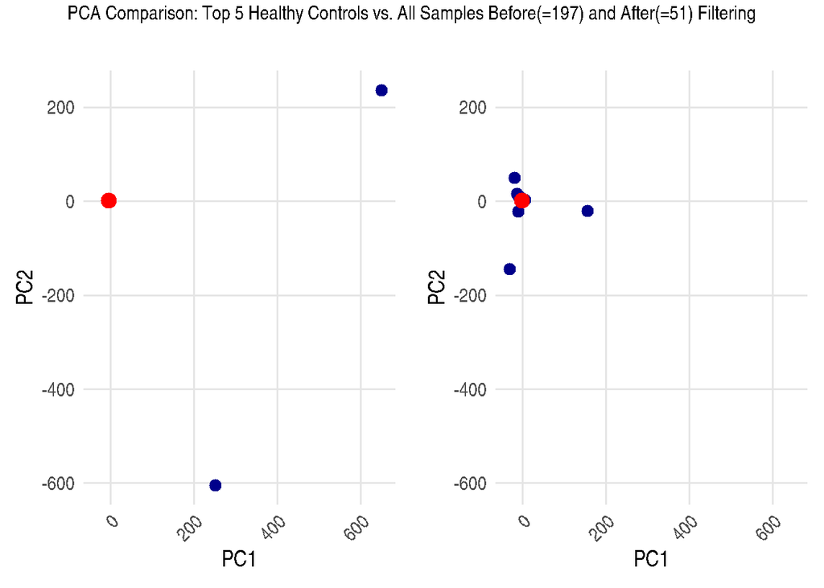

**Interpretation**

**Left plot**: In this plot that shows all healthy samples before filtering, the samples are scattered, showing more variation. The red points highlight the Top 5 Healthy Controls, which are central to the data, representing the least variation and most typical healthy profiles.

Note: Some points may appear fewer due to overlap , samples with similar PC1/PC2 values are plotted on top of each other.

This is especially common in tightly clustered, filtered data.

**Right plot**: Top 5 Healthy Controls Highlighted (Filtered Data) After applying filtering based on BMI, medications, allergies, and alcohol intake, the remaining 51 samples are plotted. The red points still represent the Top 5 Healthy Controls, which remain central in the filtered dataset, showing minimal variation.

Center and Centrality **In PCA, the “center” is the mean of all samples in the reduced space (PC1, PC2). The central samples, closest to this mean, are the most typical healthy controls.** These samples serve as a baseline for comparing deviations or disruptions in the microbiome of other individuals.

In summary, the **Top 5 Healthy Controls possibly represent stable and typical healthy profiles, providing a reliable baseline for comparison in microbiome studies.**

```
## # A tibble: 5 × 3
##   sample_id run_accession project_link
##   <chr>     <chr>         <chr>
## 1 sample031 ERR4836343    https://www.ebi.ac.uk/ena/browser/view/PRJEB41316
## 2 sample066 ERR4836378    https://www.ebi.ac.uk/ena/browser/view/PRJEB41316
## 3 sample067 ERR4836379    https://www.ebi.ac.uk/ena/browser/view/PRJEB41316
## 4 sample105 ERR4836417    https://www.ebi.ac.uk/ena/browser/view/PRJEB41316
## 5 sample137 ERR4836448    https://www.ebi.ac.uk/ena/browser/view/PRJEB41316
```

To retrieve the samples from the output:

The run_accession column contains run ID (e.g., ERR4836388, ERR4836483).

The project_link column provides a direct link to the project’s page on the European Nucleotide Archive (ENA).

Download the data by going to the main project page and select the samples of your interest via run_accession. Or use any of the files provided along with this .Rmd if they are of any use to you.

## Conclusion

We began by filtering the metadata using strict but interpretable health criteria. Specifically, we retained only those samples with:

- A body mass index (BMI) within the healthy range (18.5–25),
- No reported medications,
- No known allergies, and
- Low or no alcohol consumption (≤1–2 units per week).

This reduced the dataset to 51 high-quality, biologically clean samples suitable for defining a healthy baseline.

To identify the most representative samples among these, we applied a centered log-ratio (CLR) transformation to the OTU table, followed by principal component analysis (PCA) to reduce dimensionality while preserving variation. We then used the Mahalanobis distance on the PCA-reduced space to quantify how centrally each sample lies relative to the overall distribution. Samples with the lowest Mahalanobis distance were considered the most representative (central, not outliers), making them ideal reference points for comparison in future analyses.

Our final top 3–5 samples span multiple donors but exhibit consistent microbial profiles, positioning them as good candidates for a universal healthy baseline in microbiome analysis pipelines.